# Correlations of gage info with Pekel data

#### *All gages in the 50 Central Valley HUCs are queried*

#### Workflow

- Retrieve Pekel data from all 50 CV HUCs over 2 extents
  - ‘Unbuffered’ - full HUC
  - ‘Buffered’ - within 500m of stream extents
- Clean Pekel data
  - Restrict values to those from images with < 1% NoData pixels
- Retrieve stage height and discharge data from all CV stream gages
- Perform Pearson correlation on datasets
- Retrieve linear fit coefficients
- Apply coefficients to stream gage data to calculate missing Pekel data
- Assemble plots

The highest Pearson correlations between monthly Pekel data and monthly streamgage discharge data for each HUC are below. Bold values are > 0.5.

| HUC | Gage | Pekel data | Parameter | r |
| --- | --- | --- | --- | --- |
| 18020002 | 11351945 | unbuffered | discharge | 0.7155232 |
| 18020003 | 11362950 | unbuffered | discharge | 0.8782777 |
| 18020004 | 11367500 | unbuffered | discharge | 0.7908985 |
| 18020005 | 11342000 | unbuffered | discharge | 0.5151454 |
| 18020104 | 11389500 | buffered | discharge | 0.3228654 |
| 18020111 | 11446500 | buffered | discharge | 0.4914510 |
| 18020116 | 11450000 | unbuffered | gage ht | 0.7671927 |
| 18020121 | 11404900 | unbuffered | discharge | 0.5322698 |
| 18020122 | 11401920 | unbuffered | discharge | 0.6681172 |
| 18020123 | 11396395 | unbuffered | discharge | 0.8146864 |
| 18020125 | 11413323 | buffered | discharge | 0.8454259 |
| 18020126 | 11423800 | buffered | discharge | 0.6617975 |
| 18020128 | 11427770 | unbuffered | discharge | 0.7126676 |
| 18020129 | 11436510 | buffered | discharge | 0.7169556 |
| 18020151 | 11372330 | unbuffered | discharge | 0.7073722 |
| 18020152 | 11374300 | buffered | discharge | 0.7545100 |
| 18020153 | 11376160 | buffered | discharge | 0.6173232 |
| 18020154 | 11371600 | buffered | discharge | 0.2647834 |
| 18020155 | 11377100 | buffered | discharge | 0.6326314 |
| 18020156 | 11381500 | unbuffered | discharge | 0.6783892 |
| 18020157 | 11383500 | unbuffered | discharge | 0.6575320 |
| 18020158 | 11389720 | unbuffered | discharge | 0.5654060 |
| 18020159 | 11406930 | unbuffered | discharge | 0.2545626 |
| 18020161 | 11425500 | buffered | discharge | 0.0598704 |
| 18020162 | 11453500 | buffered | discharge | 0.5745510 |
| 18020163 | 11453000 | buffered | discharge | 0.7692464 |
| 18030001 | 11186001 | unbuffered | discharge | 0.7327307 |
| 18030002 | 11189500 | unbuffered | discharge | 0.4831582 |
| 18030003 | 11192500 | buffered | discharge | 0.7663668 |
| 18030005 | 11200800 | unbuffered | discharge | 0.4970706 |
| 18030006 | 11201450 | unbuffered | discharge | 0.7737785 |
| 18030007 | 11206820 | unbuffered | discharge | 0.8846613 |
| 18030009 | 11253310 | unbuffered | discharge | 0.4512160 |
| 18030010 | 11218700 | unbuffered | discharge | 0.7729045 |
| 18030012 | 11224500 | unbuffered | discharge | 0.3120235 |
| 18040001 | 11273400 | buffered | discharge | 0.8643214 |
| 18040002 | 11274550 | buffered | discharge | 0.9503570 |
| 18040003 | 11337600 | buffered | discharge | 0.5558578 |
| 18040006 | 11224000 | buffered | discharge | 0.8792405 |
| 18040008 | 11269700 | buffered | discharge | 0.7499117 |
| 18040009 | 11290000 | unbuffered | discharge | 0.6648866 |
| 18040010 | 11292615 | buffered | discharge | 0.8187616 |
| 18040012 | 11313482 | buffered | discharge | 0.6534017 |
| 18040013 | 11335000 | unbuffered | discharge | 0.7729845 |
| 18040014 | 11255575 | buffered | discharge | 0.2472893 |

What do the correlations look like?

Highest correlation: gage 11274550

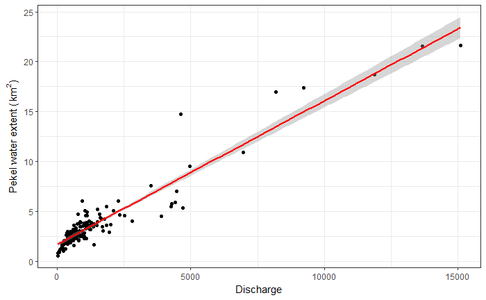

Lowest correlation: gage 11425500

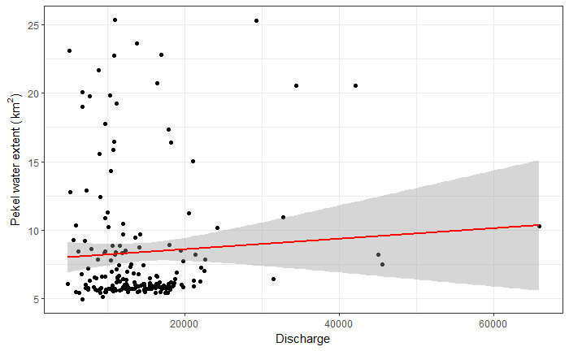

What does the max look like as far as augmenting associated Pekel data?

Max correlation:

```
Call:
lm(formula = water ~ mean_va, data = subset(pk_sg, site_no ==
    site_max & pk_type == pk_max & interp == "N"))

Residuals:
    Min      1Q  Median      3Q     Max
-3.1058 -0.4529 -0.0060  0.4273  6.4181

Coefficients:
             Estimate Std. Error t value Pr(>|t|)
(Intercept) 1.727e+00  1.007e-01   17.14   <2e-16 ***
mean_va     1.436e-03  3.827e-05   37.53   <2e-16 ***
---
Signif. codes:  0 ‘***’ 0.001 ‘**’ 0.01 ‘*’ 0.05 ‘.’ 0.1 ‘ ’ 1

Residual standard error: 1.052 on 151 degrees of freedom
Multiple R-squared:  0.9032,    Adjusted R-squared:  0.9025
F-statistic:  1409 on 1 and 151 DF,  p-value: < 2.2e-16
```

Replace missing Pekel data water values with the equation

$y = 1.7265863 + 0.0014363x_i$

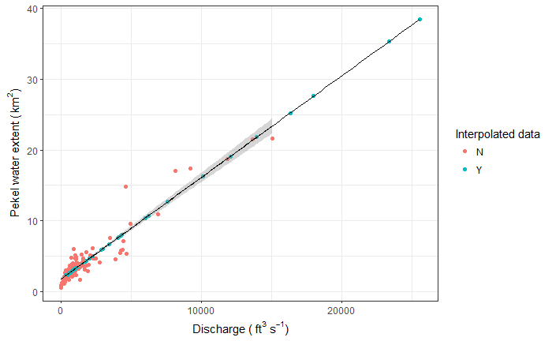

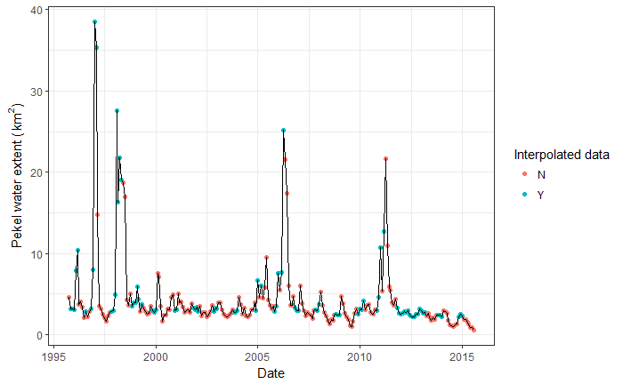

Corresponding stream gage monthly data:

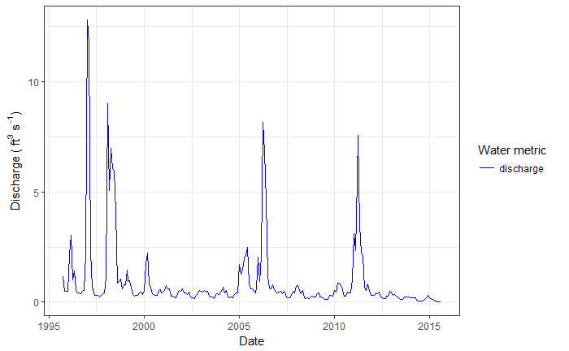

You can see that the interpolation mostly fills in low Pekel data values, but also contributes prominent peaks that were missing from the original Pekel time series.